# Inflation Parameter vs Sample Size

David Gerard

2016-06-01

# Abstract

It appears that the estimate of the variance inflation parameter depends on the sample size. When the labels are randomly permuted, we have that for small sample sizes the inflation is larger and for large sample sizes, the inflation is smaller. When I don’t permute the labels but just take subsamples of the data, the relationship is weird. This doesn’t seem to be a control-gene issue as I see similar results using SUCCOTASH.

# Data cleaning

Read in the cleaned muscle gtex data.

```r
library(ggplot2)
library(reshape2)
load(file = "../output/cleaned_gtex_data/muscle.Rd")
Y <- muscle$Y
ctl <- muscle$ctl
onsex <- muscle$chrom == "X" | muscle$chrom == "Y"
sevenfive <- apply(Y, 2, quantile, probs = 0.75) ## to deal with library size
X <- cbind(muscle$X, sevenfive)
```

$Y$ is log(COUNTS + 1) of the top 18636 expressed genes (genes with at least 10 reads per sample on average). Samples from the same individual were averaged, resulting in $n =$ 430. $X$ contains just an intercept and an indicator for sex. The idea here is that genes on sex chromosomes are “positive controls,” so the best method will be that which has the most genes on sex chromosomes among the most significant genes. This is the setup that Gagnon-Bartsch and Speed (2012) and Wang et al. (2015) use to evaluate performance between these confounder adjustment methods.

Control genes are the housekeeping genes identified by Eisenberg and Levanon (2013). This is a different list than that used by Gagnon-Bartsch and Speed (2012), which was drawn from Eisenberg and Levanon (2003). In total, there are 3609 housekeeping genes among the 18636 most expressed genes in the GTEX muscle data.

# Analysis

Take subsets of the samples and run RUVASH. Here, we let $n = 10, 20, 50, 100, 200$.

```r
set.seed(1)
k <- sva::num.sv(dat = Y, mod = X)
ruvash_out <- ashr::ash_ruv(Y = t(Y), X = X, ctl = ctl, k = k, cov_of_interest = 2)

itermax <- 100
nsamp_seq <- c(10, 20, 50, 100, 200)
mult_mat <- matrix(NA, nrow = length(nsamp_seq) * itermax + 1, ncol = 4)
colnames(mult_mat) <- c("seed", "num_sv", "nsamp", "multiplier")
mult_mat[1, ] <- c(1, k, ncol(Y), ruvash_out$ruv$multiplier)

rowindex <- 2
for (nsamp in nsamp_seq) {
    for (rep_index in 1:itermax) {
        current_seed <- nsamp + rep_index
        set.seed(current_seed)
        subcols <- sample(1:ncol(Y), size = nsamp)
        Ysub <- Y[, subcols]
        Xsub <- X[subcols, ]
        while (all(Xsub[, "Gender"] == 1) | all(Xsub[, "Gender"] == 0)) {
            subcols <- sample(1:ncol(Y), size = nsamp)
            Ysub <- Y[, subcols]
            Xsub <- X[subcols, ]
        }

        k <- sva::num.sv(dat = Ysub, mod = Xsub)
        ruvash_out <- ashr::ash_ruv(Y = t(Ysub), X = Xsub, ctl = ctl, k = k, cov_of_interest = 2)

        mult_mat[rowindex, 1] <- current_seed
        mult_mat[rowindex, 2] <- k
        mult_mat[rowindex, 3] <- nsamp
        mult_mat[rowindex, 4] <- ruvash_out$ruv$multiplier
        cat("rowindex", rowindex, "\n")
        cat("vals", mult_mat[rowindex, ], "\n")
        rowindex <- rowindex + 1
    }
}
write.csv(mult_mat, file = "mult_mat.csv", row.names = FALSE)
```

Same thing but using random labels for “treatment” and “control”.

```r
itermax <- 100
nsamp_seq <- c(10, 20, 50, 100, 200, 400)
mult_mat <- matrix(NA, nrow = length(nsamp_seq) * itermax, ncol = 4)
colnames(mult_mat) <- c("seed", "num_sv", "nsamp", "multiplier")
mult_mat[1, ] <- c(1, k, ncol(Y), ruvash_out$ruv$multiplier)

rowindex <- 1
for (nsamp in nsamp_seq) {
    for (rep_index in 1:itermax) {
        current_seed <- nsamp + rep_index
        set.seed(current_seed)
        subcols <- sample(1:ncol(Y), size = nsamp)
        Ysub <- Y[, subcols]
        Xsub <- X[subcols, ]
        Xsub[, "Gender"] <- sample(Xsub[, "Gender"])
        while (all(Xsub[, "Gender"] == 1) | all(Xsub[, "Gender"] == 0)) {
            subcols <- sample(1:ncol(Y), size = nsamp)
            Ysub <- Y[, subcols]
            Xsub <- X[subcols, ]
            Xsub[, "Gender"] <- sample(Xsub[, "Gender"])
        }
        k <- sva::num.sv(dat = Ysub, mod = Xsub)
        ruvash_out <- ashr::ash_ruv(Y = t(Ysub), X = Xsub, ctl = ctl, k = k, cov_of_interest = 2)

        mult_mat[rowindex, 1] <- current_seed
        mult_mat[rowindex, 2] <- k
        mult_mat[rowindex, 3] <- nsamp
        mult_mat[rowindex, 4] <- ruvash_out$ruv$multiplier
        cat("rowindex", rowindex, "\n")
        cat("vals", mult_mat[rowindex, ], "\n")
        rowindex <- rowindex + 1
    }
}
write.csv(mult_mat, file = "mult_mat_random_labels.csv", row.names = FALSE)
```

```r
mult_df <- as.data.frame(mult_mat)
mult_df$adhoc_mult <- mult_df$nsamp / (mult_df$nsamp - mult_df$num_sv - 3)
mult_df$lambda <- mult_df$multiplier / mult_df$adhoc_mult
write.csv(mult_df, file = "mult_mat_random_labels_with_lambda.csv", row.names = FALSE)
```

Boxplot of variance inflation parameter before and after ad-hoc multiplication. Red dashed line is as a multiplier of 1. As the sample size increases, the multiplier gets closer to 1. Without the ad-hoc multiplication, it seems to converge to a something a little less than 1. These plots are under the simulation scenario where the labels were randomly permuted.

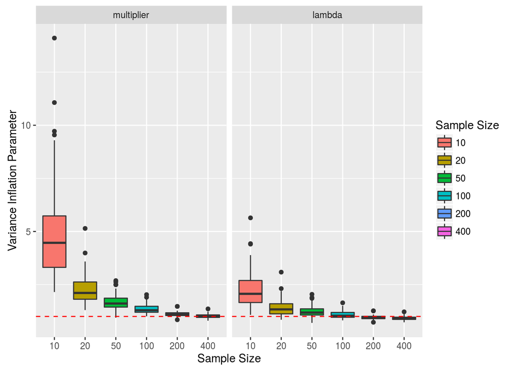

```r
mdf <- read.csv("mult_mat_random_labels_with_lambda.csv")
longdat <- melt(mdf, measure.vars = c("multiplier", "lambda"))

ggplot(data = longdat, mapping = aes(x = as.factor(nsamp), y = value,
                                     fill = as.factor(nsamp))) +
    geom_boxplot() + geom_hline(yintercept = 1, col = 2, lty = 2) +
    xlab("Sample Size") + ylab("Variance Inflation Parameter") +
    facet_grid(.~variable) +
    guides(fill = guide_legend(title="Sample Size"))
```

When I don’t randomly permute the labels, but rather just choose a random subset of observations, I see very different behavior.

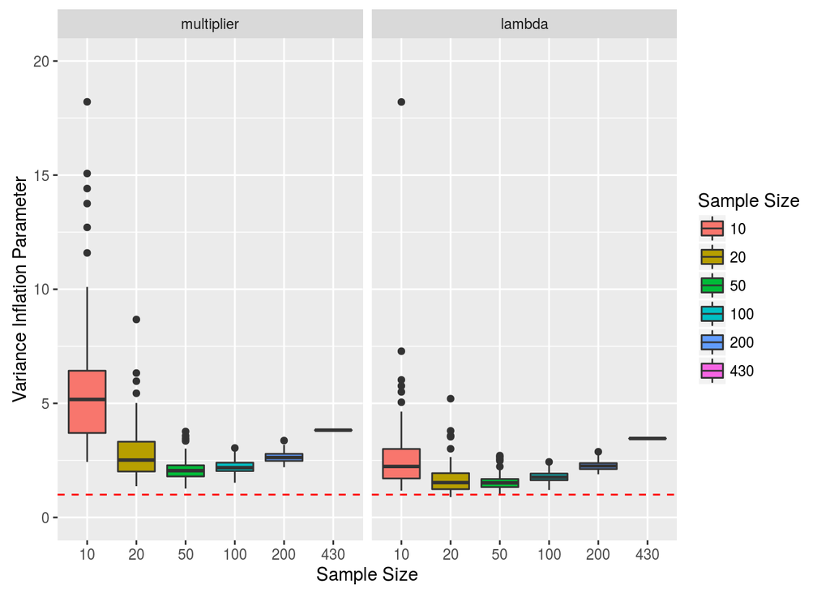

```r
mdf2 <- read.csv("mult_mat.csv")
mdf2$adhoc_mult <- mdf2$nsamp / (mdf2$nsamp - mdf2$num_sv - 3)
mdf2$lambda <- mdf2$multiplier / mdf2$adhoc_mult
longdat <- melt(mdf2, measure.vars = c("multiplier", "lambda"))

ggplot(data = longdat, mapping = aes(x = as.factor(nsamp), y = value,
                                     fill = as.factor(nsamp))) +
    geom_boxplot() + geom_hline(yintercept = 1, col = 2, lty = 2) +
    xlab("Sample Size") + ylab("Variance Inflation Parameter") +
    facet_grid(.~variable) +
    guides(fill = guide_legend(title="Sample Size")) +
    ylim(0, 20)
```

It might be the misclassification of control genes. In the permuted labels case, all of the genes are null. But when we are just taking subsets of observations, there are real effects. It might be that the control genes are mispecified. We can run SUCCOTASH on the GTEX data and compare its estimated variance inflation parameter.

```r
sevenfive <- apply(muscle$Y, 2, quantile, probs = 0.75) ## to deal with library size
X <- cbind(sevenfive, muscle$X)
succ_out <- succotashr::succotash(Y = t(muscle$Y), X = X, optmethod = "em")
```

```
## k not provided so using sva::num.sv()
## to estimate the number of hidden confounders
```

But the estimate is actually really close to what we are getting with RUVASH.

```r
succ_out$scale_val
```

```
## [1] 4.053
```

If we permute the labels of $X$, does succotash not have as large a variance inflation parameter?

```r
set.seed(6882)
X[, "Gender"] <- sample(X[, "Gender"])
succ_out2 <- succotashr::succotash(Y = t(muscle$Y), X = X, optmethod = "em")
```

```
## k not provided so using sva::num.sv()
## to estimate the number of hidden confounders
```

No, it is very close to 1:

```r
succ_out2$scale_val
```

```
## [1] 1.292
```

# References

Eisenberg, Eli, and Erez Y Levanon. 2003. “Human Housekeeping Genes Are Compact.” *TRENDS in Genetics* 19 (7). Elsevier: 362–65.

———. 2013. “Human Housekeeping Genes, Revisited.” *Trends in Genetics* 29 (10). Elsevier: 569–74.

Gagnon-Bartsch, Johann A, and Terence P Speed. 2012. “Using Control Genes to Correct for Unwanted Variation in Microarray Data.” *Biostatistics* 13 (3). Biometrika Trust: 539–52.

Wang, Jingshu, Qingyuan Zhao, Trevor Hastie, and Art B Owen. 2015. “Confounder Adjustment in Multiple Hypotheses Testing.” *ArXiv Preprint ArXiv:1508.04178*.